# Lab 7 - Neural Nets

- Neural Net for Classification
  - Preprocessing
  - Training the Model
  - Assessing the Classification Performance
  - Plotting the Network
  - Tweaking the Model
- Neural Net for Prediction
  - Preprocessing
  - Training the Model
  - Plotting the Network
  - Assessing the Predictive Performance
  - Tweaking the Model
- Summary

In this lab, we will develop neural network models to predict whether car accidents result in injuries/fatalities (a classification task) and to predict the price of used Toyota Corollas (a prediction task).

We will need the following packages for this lab:

```r
library(neuralnet)
library(nnet)
library(caret)
```

# Neural Net for Classification

In the *accidentsnn.csv* file, U.S. automobile accidents have been classified by their level of severity as *no injury*, *injury*, or *fatality*. It may be worthwhile to develop a system to quickly classify the severity of an accident based on initial reports and associated data in order to appropriately assign emergency response team priorities. The dataset contains the following variables:

- *ALCHL_I*: the presence (1) or absense(2) of alcohol
- *PROFIL_I_R*: profile of the roadway - level (1) or other (0)
- *SUR_COND*: surface condition of the road - dry (1), wet (2), snow/slush (3), ice (4), or unknown (9)
- *VEH_INVL*: the number of vehicles involved
- *MAX_SEV_IR*: the presence of injuries/fatalities - no injuries (0), injury (1), or fatality (2)

## Preprocessing

Load the data and take a look at the summary.

```r
# load the data
accidents.df <- read.csv("accidentsnn.csv")
summary(accidents.df)
```

```
##     ALCHL_I        PROFIL_I_R        SUR_COND        VEH_INVL
##  Min.   :1.000   Min.   :0.0000   Min.   :1.000   Min.   :1.0
##  1st Qu.:2.000   1st Qu.:0.0000   1st Qu.:1.000   1st Qu.:1.0
##  Median :2.000   Median :0.0000   Median :1.000   Median :1.0
##  Mean   :1.877   Mean   :0.2282   Mean   :1.309   Mean   :1.3
##  3rd Qu.:2.000   3rd Qu.:0.0000   3rd Qu.:1.000   3rd Qu.:2.0
##  Max.   :2.000   Max.   :1.0000   Max.   :9.000   Max.   :5.0
##    MAX_SEV_IR
##  Min.   :0.0000
##  1st Qu.:0.0000
##  Median :0.0000
##  Mean   :0.5976
##  3rd Qu.:1.0000
##  Max.   :2.0000
```

Recall that all variables must be standardized to a [0,1] scale. We will need to convert *ALCHL_I*, *SUR_COND*, and *MAX_SEV_IR* to binary dummy variables, and we will need to rescale *VEH_INVL* to a [0,1] scale.

We can easily convert *ALCHL_I* to a binary dummy variable using an ifelse() function.

```r
accidents.df$ALCHL_I <- ifelse(accidents.df$ALCHL_I == 1, 1, 0)
summary(accidents.df$ALCHL_I)
```

```
##    Min. 1st Qu.  Median    Mean 3rd Qu.    Max.
##  0.0000  0.0000  0.0000  0.1231  0.0000  1.0000
```

We then convert *SUR_COND* to a factor and use the model.matrix() function to create dummy variables for each level of *SUR_COND* leaving out one dummy.

```r
accidents.df$SUR_COND <- as.factor(accidents.df$SUR_COND)
dummies <- as.data.frame(model.matrix(~ 0 + SUR_COND, data = accidents.df))
t(t(names(dummies)))
```

```
##      [,1]
## [1,] "SUR_COND1"
## [2,] "SUR_COND2"
## [3,] "SUR_COND3"
## [4,] "SUR_COND4"
## [5,] "SUR_COND9"
```

```r
t(t(names(accidents.df)))
```

```
##      [,1]
## [1,] "ALCHL_I"
## [2,] "PROFIL_I_R"
## [3,] "SUR_COND"
## [4,] "VEH_INVL"
## [5,] "MAX_SEV_IR"
```

```r
# drop original SUR_COND variable and one dummy variable
accidents.df <- cbind(accidents.df[, -3], dummies[, -5])
t(t(names(accidents.df)))
```

```
##      [,1]
## [1,] "ALCHL_I"
## [2,] "PROFIL_I_R"
## [3,] "VEH_INVL"
## [4,] "MAX_SEV_IR"
## [5,] "SUR_COND1"
## [6,] "SUR_COND2"
## [7,] "SUR_COND3"
## [8,] "SUR_COND4"
```

We then standardize *VEH_INVL* to a [0,1] scale by subtracting by its minimum value and dividing by its range for every record.

```r
accidents.df$VEH_INVL <- (accidents.df$VEH_INVL - min(accidents.df$VEH_INVL)) /
  (max(accidents.df$VEH_INVL) - min(accidents.df$VEH_INVL))
summary(accidents.df$VEH_INVL)
```

```
##    Min. 1st Qu.  Median    Mean 3rd Qu.    Max.
## 0.00000 0.00000 0.00000 0.07508 0.25000 1.00000
```

We then convert *MAX_SEV_IR* to a factor and partition the data, using 60% of the records for the training sample and 40% for the validation.

```r
# convert MAX_SEV_IR to a factor
accidents.df$MAX_SEV_IR <- as.factor(accidents.df$MAX_SEV_IR)

# partition the data
set.seed(2)
train.index <- sample(nrow(accidents.df), nrow(accidents.df)*0.6)
valid.index <- setdiff(row.names(accidents.df), train.index)
acc.train <- accidents.df[train.index, ]
acc.valid <- accidents.df[valid.index, ]

summary(acc.train)
```

```
##     ALCHL_I         PROFIL_I_R        VEH_INVL       MAX_SEV_IR
##  Min.   :0.0000   Min.   :0.0000   Min.   :0.00000   0:335
##  1st Qu.:0.0000   1st Qu.:0.0000   1st Qu.:0.00000   1:171
##  Median :0.0000   Median :0.0000   Median :0.00000   2: 93
##  Mean   :0.1369   Mean   :0.2387   Mean   :0.07179
##  3rd Qu.:0.0000   3rd Qu.:0.0000   3rd Qu.:0.00000
##  Max.   :1.0000   Max.   :1.0000   Max.   :1.00000
##    SUR_COND1        SUR_COND2        SUR_COND3          SUR_COND4
##  Min.   :0.0000   Min.   :0.0000   Min.   :0.000000   Min.   :0.00000
##  1st Qu.:1.0000   1st Qu.:0.0000   1st Qu.:0.000000   1st Qu.:0.00000
##  Median :1.0000   Median :0.0000   Median :0.000000   Median :0.00000
##  Mean   :0.7947   Mean   :0.1686   Mean   :0.006678   Mean   :0.02337
##  3rd Qu.:1.0000   3rd Qu.:0.0000   3rd Qu.:0.000000   3rd Qu.:0.00000
##  Max.   :1.0000   Max.   :1.0000   Max.   :1.000000   Max.   :1.00000
```

## Training the Model

The data is now ready to be used in building a neural net model. We will begin by creating a model with a single hidden layer containing two nodes.

```r
# run nn with 2 hidden nodes
# use hidden= with a vector of integers specifying number of nodes in each hidden layer
nn <- neuralnet(MAX_SEV_IR ~ ., data = acc.train, hidden = 2)
```

## Plotting the Network

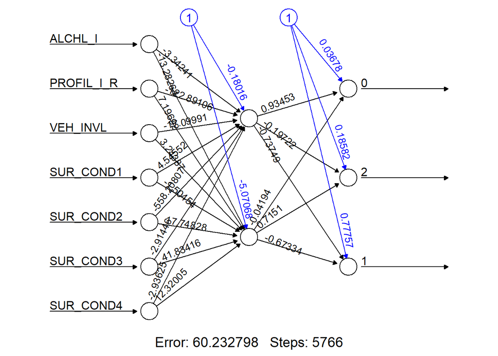

```r
# plot the network
plot(nn, rep = "best")
```

We can see in the plot that the total error for this tree is 60.232798, and it required 5,766 iterations through the data to satisfy the stopping criteria.

## Assessing the Classification Performance

Let’s take a look at the classification performance for this model. We use the compute() function to calculate the output values based on the neural net model using all predictors. We then use the apply() function to determine which class (column) yields the largest output. (We subract 1 in this step because the result would be the column number, and we want the result to be in {0, 1, 2}.)

In-Sample:

```r
training.prediction <- compute(nn, acc.train[, -4])
training.class <- apply(training.prediction$net.result, 1, which.max) - 1
confusionMatrix(as.factor(training.class), as.factor(accidents.df[train.index, ]$MAX_SEV_IR))
```

```
## Confusion Matrix and Statistics
##
##           Reference
## Prediction   0   1   2
##          0 334   0  35
##          1   0 164  34
##          2   1   7  24
##
## Overall Statistics
##
##                Accuracy : 0.8715
##                  95% CI : (0.842, 0.8972)
##     No Information Rate : 0.5593
##     P-Value [Acc > NIR] : < 2.2e-16
##
##                   Kappa : 0.7675
##
##  Mcnemar's Test P-Value : NA
##
## Statistics by Class:
##
##                      Class: 0 Class: 1 Class: 2
## Sensitivity            0.9970   0.9591  0.25806
## Specificity            0.8674   0.9206  0.98419
## Pos Pred Value         0.9051   0.8283  0.75000
## Neg Pred Value         0.9957   0.9825  0.87831
## Prevalence             0.5593   0.2855  0.15526
## Detection Rate         0.5576   0.2738  0.04007
## Detection Prevalence   0.6160   0.3306  0.05342
## Balanced Accuracy      0.9322   0.9398  0.62113
```

Out-of-Sample:

```r
validation.prediction <- compute(nn, acc.valid[, -4])
validation.class <- apply(validation.prediction$net.result, 1, which.max) - 1
confusionMatrix(as.factor(validation.class), as.factor(accidents.df[valid.index, ]$MAX_SEV_IR))
```

```
## Confusion Matrix and Statistics
##
##           Reference
## Prediction   0   1   2
##          0 216   0  20
##          1   0 123  23
##          2   0   5  13
##
## Overall Statistics
##
##                Accuracy : 0.88
##                  95% CI : (0.8441, 0.9102)
##     No Information Rate : 0.54
##     P-Value [Acc > NIR] : < 2.2e-16
##
##                   Kappa : 0.7851
##
##  Mcnemar's Test P-Value : NA
##
## Statistics by Class:
##
##                      Class: 0 Class: 1 Class: 2
## Sensitivity            1.0000   0.9609   0.2321
## Specificity            0.8913   0.9154   0.9855
## Pos Pred Value         0.9153   0.8425   0.7222
## Neg Pred Value         1.0000   0.9803   0.8874
## Prevalence             0.5400   0.3200   0.1400
## Detection Rate         0.5400   0.3075   0.0325
## Detection Prevalence   0.5900   0.3650   0.0450
## Balanced Accuracy      0.9457   0.9382   0.6088
```

This model performs quite well at predicting accidents with no injuries or with injuries, but it performs quite poorly predicting fatalities (even on the training dataset). Let’s try adding some complexity to the model.

## Tweaking the Model

We now try a neural net with 2 hidden layers of 2 nodes each. We specify a very large “stepmax” here to ensure that the complex model doesn’t time out before completion.

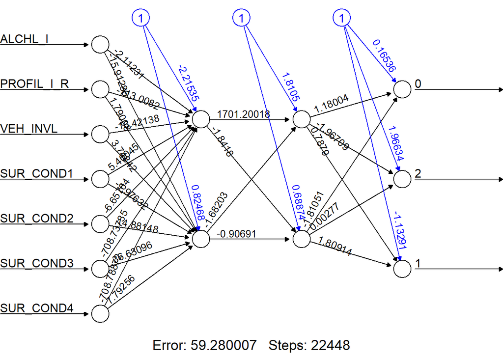

```r
nn.2.2 <- neuralnet(MAX_SEV_IR ~ ., data = acc.train, hidden = c(2, 2), stepmax = 1e6)

# plot the network
plot(nn.2.2, rep = "best")
```

```r
training.prediction2.2 <- compute(nn.2.2, acc.train[, -4])
training.class2.2 <- apply(training.prediction2.2$net.result, 1, which.max) - 1
confusionMatrix(as.factor(training.class2.2), as.factor(accidents.df[train.index, ]$MAX_SEV_IR))
```

```
## Confusion Matrix and Statistics
##
##           Reference
## Prediction   0   1   2
##          0 333   0  34
##          1   0 164  36
##          2   2   7  23
##
## Overall Statistics
##
##                Accuracy : 0.8681
##                  95% CI : (0.8384, 0.8942)
##     No Information Rate : 0.5593
##     P-Value [Acc > NIR] : < 2.2e-16
##
##                   Kappa : 0.7618
##
##  Mcnemar's Test P-Value : NA
##
## Statistics by Class:
##
##                      Class: 0 Class: 1 Class: 2
## Sensitivity            0.9940   0.9591  0.24731
## Specificity            0.8712   0.9159  0.98221
## Pos Pred Value         0.9074   0.8200  0.71875
## Neg Pred Value         0.9914   0.9825  0.87654
## Prevalence             0.5593   0.2855  0.15526
## Detection Rate         0.5559   0.2738  0.03840
## Detection Prevalence   0.6127   0.3339  0.05342
## Balanced Accuracy      0.9326   0.9375  0.61476
```

The sensitivity for fatalities (class 2) still leaves much to be desired. Try playing around with the number of hidden layers and corresponding nodes to see if the class 2 sensitivity immproves. It is possible that, while the model does a good job at distinguishing no-injury accidents from accidents with injuries, the predictors may be insufficient for determining fatalities. It would likely be useful to have information regarding seatbelt usage, site of impact, where/how the car ended up, etc.

# Neural Net for Prediction

Recall the *ToyotaCorolla.csv* file which contains data on used Toyota Corolla sales where the goal is to predict the price of a used Toyota Corolla based on its specifications. We are going to create a neural net model using *Age_08_04*, *KM*, *Fuel_Type*, *HP*, *Automatic*, *Doors*, *Quarterly_Tax*, *Mfr_Guarantee*, *Guarantee_Period*, *Airco*, *Automatic_airco*, *CD_Player*, *Powered_Windows*, *Sport_Model*, and *Tow_Bar* to predict *Price*.

## Preprocessing

We load the data and extract only the variables we’ll be using in the analysis.

```r
toyota.df <- read.csv("ToyotaCorolla.csv")
t(t(names(toyota.df)))
```

```
##       [,1]
##  [1,] "Id"
##  [2,] "Model"
##  [3,] "Price"
##  [4,] "Age_08_04"
##  [5,] "Mfg_Month"
##  [6,] "Mfg_Year"
##  [7,] "KM"
##  [8,] "Fuel_Type"
##  [9,] "HP"
## [10,] "Met_Color"
## [11,] "Color"
## [12,] "Automatic"
## [13,] "CC"
## [14,] "Doors"
```

[output cut: 25 more lines]

```r
toyota.sub <- toyota.df[, c(3:4, 8:9, 12, 14, 17, 19, 21, 25:26, 28, 30, 34, 39)]
str(toyota.sub)
```

```
## 'data.frame':    1436 obs. of  15 variables:
##  $ Price           : int  13500 13750 13950 14950 13750 12950 16900 18600 21500 12950 ...
##  $ Age_08_04       : int  23 23 24 26 30 32 27 30 27 23 ...
##  $ Fuel_Type       : Factor w/ 3 levels "CNG","Diesel",..: 2 2 2 2 2 2 2 2 3 2 ...
##  $ HP              : int  90 90 90 90 90 90 90 90 192 69 ...
##  $ Automatic       : int  0 0 0 0 0 0 0 0 0 0 ...
##  $ Doors           : int  3 3 3 3 3 3 3 3 3 3 ...
##  $ Quarterly_Tax   : int  210 210 210 210 210 210 210 210 100 185 ...
##  $ Mfr_Guarantee   : int  0 0 1 1 1 0 0 1 0 0 ...
##  $ Guarantee_Period: int  3 3 3 3 3 3 3 3 3 3 ...
##  $ Airco           : int  0 1 0 0 1 1 1 1 1 1 ...
##  $ Automatic_airco : int  0 0 0 0 0 0 0 0 0 0 ...
##  $ CD_Player       : int  0 1 0 0 0 0 0 1 0 0 ...
##  $ Powered_Windows : int  1 0 0 0 1 1 1 1 1 0 ...
##  $ Sport_Model     : int  0 0 0 0 0 0 1 0 0 0 ...
##  $ Tow_Bar         : int  0 0 0 0 0 0 0 0 0 0 ...
```

```r
summary(toyota.sub)
```

```
##      Price         Age_08_04      Fuel_Type          HP
##  Min.   : 4350   Min.   : 1.00   CNG   :  17   Min.   : 69.0
##  1st Qu.: 8450   1st Qu.:44.00   Diesel: 155   1st Qu.: 90.0
##  Median : 9900   Median :61.00   Petrol:1264   Median :110.0
##  Mean   :10731   Mean   :55.95                 Mean   :101.5
##  3rd Qu.:11950   3rd Qu.:70.00                 3rd Qu.:110.0
##  Max.   :32500   Max.   :80.00                 Max.   :192.0
##    Automatic           Doors       Quarterly_Tax    Mfr_Guarantee
##  Min.   :0.00000   Min.   :2.000   Min.   : 19.00   Min.   :0.0000
##  1st Qu.:0.00000   1st Qu.:3.000   1st Qu.: 69.00   1st Qu.:0.0000
##  Median :0.00000   Median :4.000   Median : 85.00   Median :0.0000
##  Mean   :0.05571   Mean   :4.033   Mean   : 87.12   Mean   :0.4095
##  3rd Qu.:0.00000   3rd Qu.:5.000   3rd Qu.: 85.00   3rd Qu.:1.0000
##  Max.   :1.00000   Max.   :5.000   Max.   :283.00   Max.   :1.0000
##  Guarantee_Period     Airco        Automatic_airco     CD_Player
##  Min.   : 3.000   Min.   :0.0000   Min.   :0.00000   Min.   :0.0000
##  1st Qu.: 3.000   1st Qu.:0.0000   1st Qu.:0.00000   1st Qu.:0.0000
##  Median : 3.000   Median :1.0000   Median :0.00000   Median :0.0000
##  Mean   : 3.815   Mean   :0.5084   Mean   :0.05641   Mean   :0.2187
##  3rd Qu.: 3.000   3rd Qu.:1.0000   3rd Qu.:0.00000   3rd Qu.:0.0000
##  Max.   :36.000   Max.   :1.0000   Max.   :1.00000   Max.   :1.0000
##  Powered_Windows  Sport_Model        Tow_Bar
##  Min.   :0.000   Min.   :0.0000   Min.   :0.0000
##  1st Qu.:0.000   1st Qu.:0.0000   1st Qu.:0.0000
##  Median :1.000   Median :0.0000   Median :0.0000
##  Mean   :0.562   Mean   :0.3001   Mean   :0.2779
##  3rd Qu.:1.000   3rd Qu.:1.0000   3rd Qu.:1.0000
##  Max.   :1.000   Max.   :1.0000   Max.   :1.0000
```

Neural nets’ performance can be negatively affected by highly skewed predictors, so a log transformation should be applied to highly skewed predictors prior to building any models. Highly skewed predictors can be identified using box plots and/or the skewness() function in the *e1071* package.

Here we look at all the numerical predictors in *toyota.sub*.

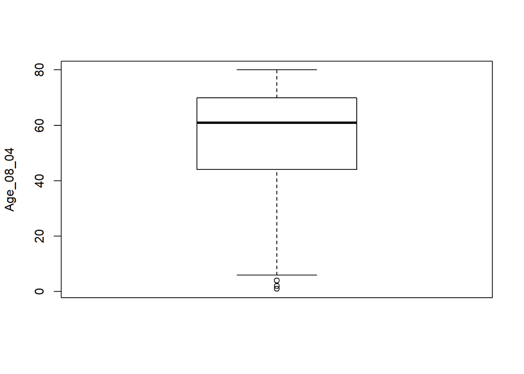

```
## [1] -0.8249756
```

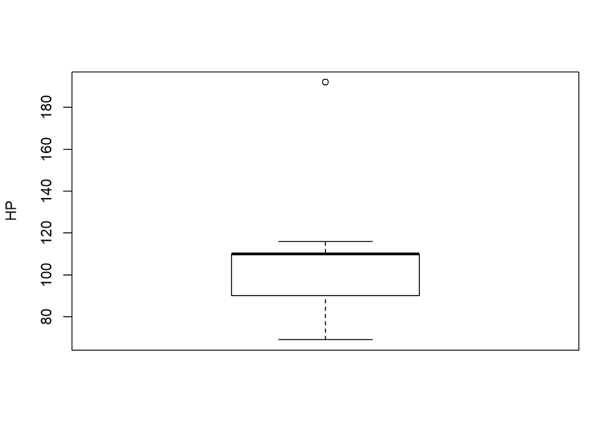

```
## [1] 0.9538397
```

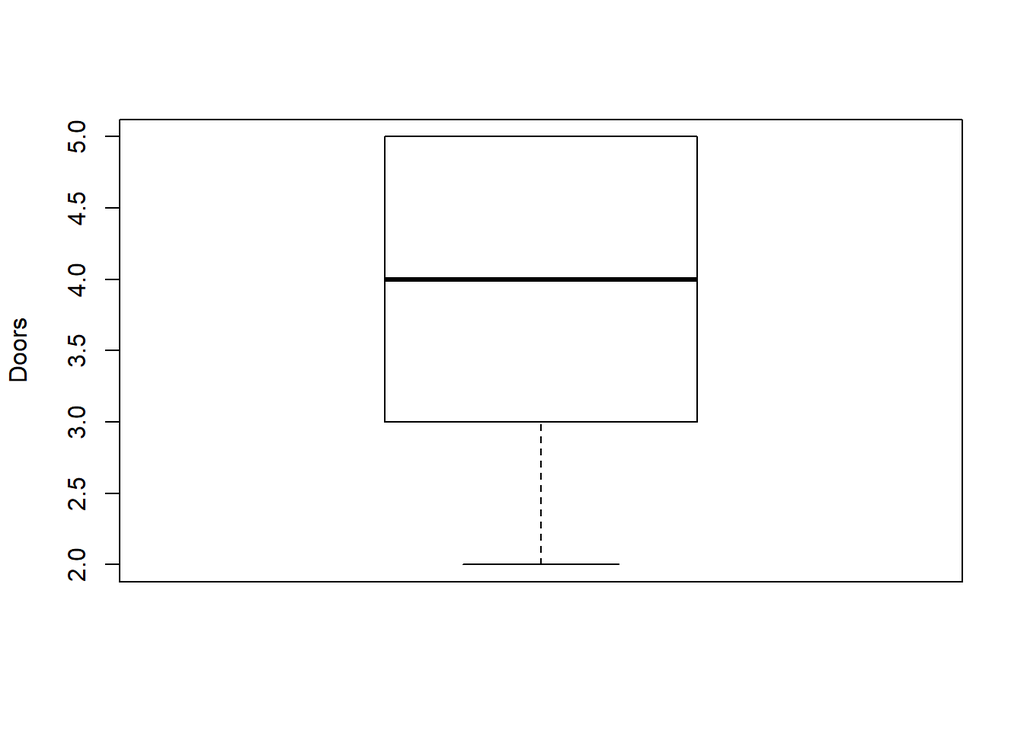

```
## [1] -0.07623547
```

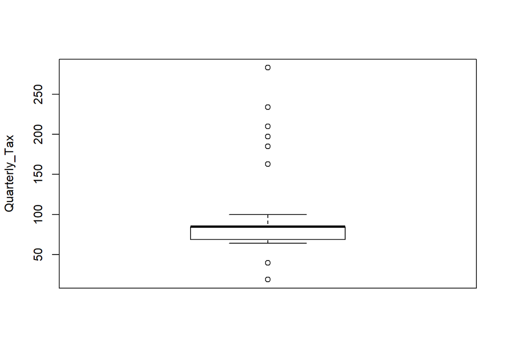

```
## [1] 1.98967
```

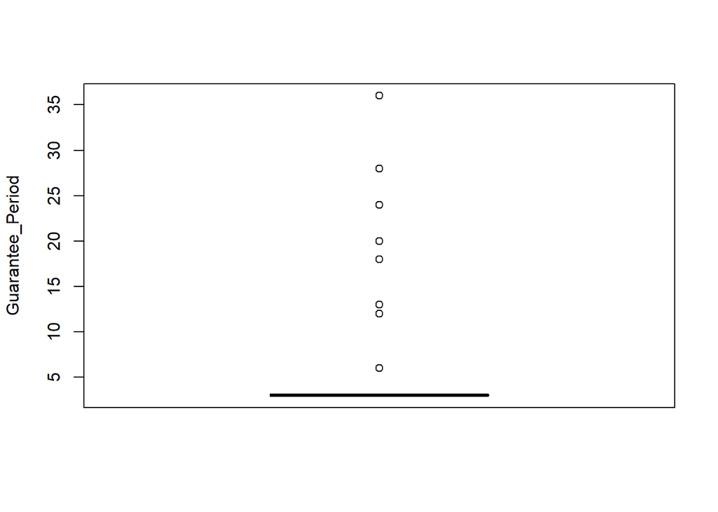

```
## [1] 5.826243
```

```r
library(e1071)
num.cols <- colnames(toyota.sub[, c(2,4,6:7,9)])
for (i in num.cols) {
  boxplot(toyota.sub[[i]],
          ylab = i)
  print(skewness(toyota.sub[[i]]))
}
```

Generally, a variable is considered highly skewed if the absolute value of the skewness is greater than 1. In this case, we see that *Quarterly_Tax* and *Guarantee_Period* are highly skewed, so we apply a log transformation.

```r
toyota.sub$Quarterly_Tax <- log(toyota.sub$Quarterly_Tax + 1)
toyota.sub$Guarantee_Period <- log(toyota.sub$Guarantee_Period + 1)
```

(We actually take the natural log of the variable *plus 1* in order to avoid errors when the variable’s value is 0.)

*Fuel_Type* must be converted to binary dummy variables, leaving one out in the process.

```r
dummies <- as.data.frame(model.matrix(~ 0 + Fuel_Type, data = toyota.sub))
t(t(names(dummies)))
```

```
##      [,1]
## [1,] "Fuel_TypeCNG"
## [2,] "Fuel_TypeDiesel"
## [3,] "Fuel_TypePetrol"
```

```r
t(t(names(toyota.sub)))
```

```
##       [,1]
##  [1,] "Price"
##  [2,] "Age_08_04"
##  [3,] "Fuel_Type"
##  [4,] "HP"
##  [5,] "Automatic"
##  [6,] "Doors"
##  [7,] "Quarterly_Tax"
##  [8,] "Mfr_Guarantee"
##  [9,] "Guarantee_Period"
## [10,] "Airco"
## [11,] "Automatic_airco"
## [12,] "CD_Player"
## [13,] "Powered_Windows"
## [14,] "Sport_Model"
## [15,] "Tow_Bar"
```

```r
toyota.sub <- cbind(toyota.sub[, -3], dummies[, -3])
summary(toyota.sub)
```

```
##      Price         Age_08_04           HP          Automatic
##  Min.   : 4350   Min.   : 1.00   Min.   : 69.0   Min.   :0.00000
##  1st Qu.: 8450   1st Qu.:44.00   1st Qu.: 90.0   1st Qu.:0.00000
##  Median : 9900   Median :61.00   Median :110.0   Median :0.00000
##  Mean   :10731   Mean   :55.95   Mean   :101.5   Mean   :0.05571
##  3rd Qu.:11950   3rd Qu.:70.00   3rd Qu.:110.0   3rd Qu.:0.00000
##  Max.   :32500   Max.   :80.00   Max.   :192.0   Max.   :1.00000
##      Doors       Quarterly_Tax   Mfr_Guarantee    Guarantee_Period
##  Min.   :2.000   Min.   :2.996   Min.   :0.0000   Min.   :1.386
##  1st Qu.:3.000   1st Qu.:4.248   1st Qu.:0.0000   1st Qu.:1.386
##  Median :4.000   Median :4.454   Median :0.0000   Median :1.386
##  Mean   :4.033   Mean   :4.386   Mean   :0.4095   Mean   :1.492
##  3rd Qu.:5.000   3rd Qu.:4.454   3rd Qu.:1.0000   3rd Qu.:1.386
##  Max.   :5.000   Max.   :5.649   Max.   :1.0000   Max.   :3.611
##      Airco        Automatic_airco     CD_Player      Powered_Windows
##  Min.   :0.0000   Min.   :0.00000   Min.   :0.0000   Min.   :0.000
##  1st Qu.:0.0000   1st Qu.:0.00000   1st Qu.:0.0000   1st Qu.:0.000
##  Median :1.0000   Median :0.00000   Median :0.0000   Median :1.000
##  Mean   :0.5084   Mean   :0.05641   Mean   :0.2187   Mean   :0.562
##  3rd Qu.:1.0000   3rd Qu.:0.00000   3rd Qu.:0.0000   3rd Qu.:1.000
##  Max.   :1.0000   Max.   :1.00000   Max.   :1.0000   Max.   :1.000
##   Sport_Model        Tow_Bar        Fuel_TypeCNG     Fuel_TypeDiesel
##  Min.   :0.0000   Min.   :0.0000   Min.   :0.00000   Min.   :0.0000
##  1st Qu.:0.0000   1st Qu.:0.0000   1st Qu.:0.00000   1st Qu.:0.0000
##  Median :0.0000   Median :0.0000   Median :0.00000   Median :0.0000
##  Mean   :0.3001   Mean   :0.2779   Mean   :0.01184   Mean   :0.1079
##  3rd Qu.:1.0000   3rd Qu.:1.0000   3rd Qu.:0.00000   3rd Qu.:0.0000
##  Max.   :1.0000   Max.   :1.0000   Max.   :1.00000   Max.   :1.0000
```

We then rescale all variables to a [0,1] scale using the preProcess() function with method=“range”.

```r
norm.values <- preProcess(toyota.sub, method = "range")
toyota.norm <- predict(norm.values, toyota.sub)
summary(toyota.norm)
```

```
##      Price          Age_08_04            HP           Automatic
##  Min.   :0.0000   Min.   :0.0000   Min.   :0.0000   Min.   :0.00000
##  1st Qu.:0.1456   1st Qu.:0.5443   1st Qu.:0.1707   1st Qu.:0.00000
##  Median :0.1972   Median :0.7595   Median :0.3333   Median :0.00000
##  Mean   :0.2267   Mean   :0.6955   Mean   :0.2642   Mean   :0.05571
##  3rd Qu.:0.2700   3rd Qu.:0.8734   3rd Qu.:0.3333   3rd Qu.:0.00000
##  Max.   :1.0000   Max.   :1.0000   Max.   :1.0000   Max.   :1.00000
##      Doors        Quarterly_Tax    Mfr_Guarantee    Guarantee_Period
##  Min.   :0.0000   Min.   :0.0000   Min.   :0.0000   Min.   :0.00000
##  1st Qu.:0.3333   1st Qu.:0.4722   1st Qu.:0.0000   1st Qu.:0.00000
##  Median :0.6667   Median :0.5497   Median :0.0000   Median :0.00000
##  Mean   :0.6778   Mean   :0.5240   Mean   :0.4095   Mean   :0.04752
##  3rd Qu.:1.0000   3rd Qu.:0.5497   3rd Qu.:1.0000   3rd Qu.:0.00000
##  Max.   :1.0000   Max.   :1.0000   Max.   :1.0000   Max.   :1.00000
##      Airco        Automatic_airco     CD_Player      Powered_Windows
##  Min.   :0.0000   Min.   :0.00000   Min.   :0.0000   Min.   :0.000
##  1st Qu.:0.0000   1st Qu.:0.00000   1st Qu.:0.0000   1st Qu.:0.000
##  Median :1.0000   Median :0.00000   Median :0.0000   Median :1.000
##  Mean   :0.5084   Mean   :0.05641   Mean   :0.2187   Mean   :0.562
##  3rd Qu.:1.0000   3rd Qu.:0.00000   3rd Qu.:0.0000   3rd Qu.:1.000
##  Max.   :1.0000   Max.   :1.00000   Max.   :1.0000   Max.   :1.000
##   Sport_Model        Tow_Bar        Fuel_TypeCNG     Fuel_TypeDiesel
##  Min.   :0.0000   Min.   :0.0000   Min.   :0.00000   Min.   :0.0000
##  1st Qu.:0.0000   1st Qu.:0.0000   1st Qu.:0.00000   1st Qu.:0.0000
##  Median :0.0000   Median :0.0000   Median :0.00000   Median :0.0000
##  Mean   :0.3001   Mean   :0.2779   Mean   :0.01184   Mean   :0.1079
##  3rd Qu.:1.0000   3rd Qu.:1.0000   3rd Qu.:0.00000   3rd Qu.:0.0000
##  Max.   :1.0000   Max.   :1.0000   Max.   :1.00000   Max.   :1.0000
```

Now that the variables are all in the proper format, we partition the data.

```r
set.seed(41)
train.index <- sample(nrow(toyota.norm), nrow(toyota.norm)*0.6)
toyota.train <- toyota.norm[train.index, ]
toyota.valid <- toyota.norm[-train.index, ]
```

## Training the Model

We will begin by training a neural net model with a single hidden layer containing two nodes.

```r
nn1 <- neuralnet(Price ~ ., data = toyota.train, linear.output = FALSE, hidden = 2)
```

```r
nn1$response[1, ]
```

```
## [1] 0.5417407
```

Recall that when predicting a numerical/continuous outcome, you will need to rescale the output to its original units by multiplying by the original range and adding the original minimum.

```r
nn1$response[1, ]*(max(toyota.df$Price) - min(toyota.df$Price)) + min(toyota.df$Price)
```

```
## [1] 19600
```

## Plotting the Network

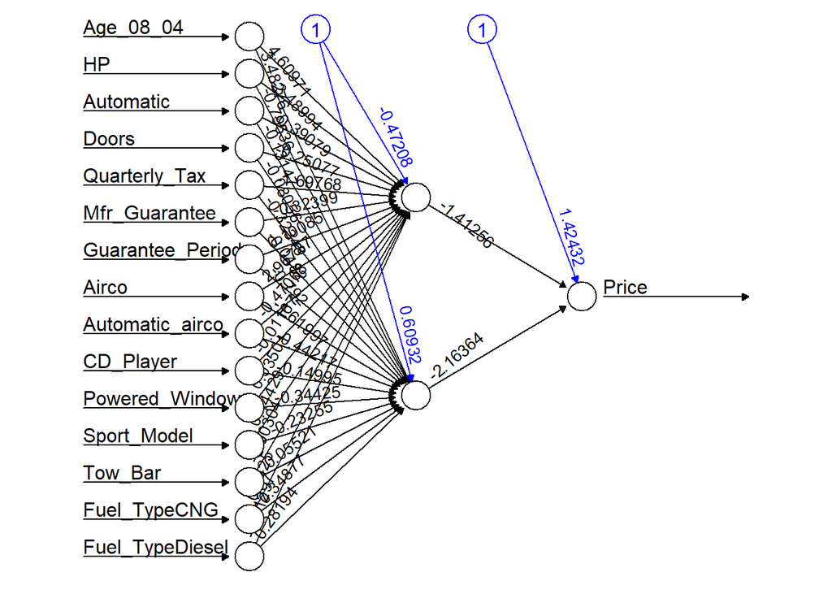

```r
plot(nn1, rep = "best")
```

## Assessing the Predictive Performance

As with other prediction algorithms, we will use root mean square error (RMSE) to assess the predictive performance of the model. We use the compute() function to calculate the predicted price based on the predictors and then use the RMSE() function to calculate RMSE.

In-Sample:

```r
predict1.train <- compute(nn1, toyota.train[, c(2:16)])
RMSE(predict1.train$net.result, toyota.train$Price)
```

```
## [1] 0.03961706
```

Out-of-Sample:

```r
predict1.valid <- compute(nn1, toyota.valid[, c(2:16)])
RMSE(predict1.valid$net.result, toyota.valid$Price)
```

```
## [1] 0.04682752
```

## Tweaking the Model

**Exercise**:

- Repeat the process changing the number of hidden layers and nodes to:
  - a single hidden layer with 5 nodes
  - two hidden layers with 5 nodes in each layer
- What happens to the RMSE for the training data as the number of layers and nodes increases?
- What happens to the RMSE for the validation data?
- What can you say about the appropriate number of layers and nodes for this application?

# Summary

- Neural networks perform very well for both classification and prediction tasks.
- Neural nets capture very complex relationships among predictors and outcome variables.
- Neural nets are “black box” in nature making the results difficult to interpret.
- All variables should be standardized to a [0, 1] scale prior to inputting them into the model.
- Categorical variables must be converted to binary dummy variables.
- For predicting a continuous outcome, the output value must be rescaled to its original units.